# Electrical equipment fault prediction

Nanda Zahri Wibowo

June 22, 2026

# Introduction

## Background

Predictive maintenance has emerged as a critical capability in modern industrial operations, particularly within the context of Industry 4.0. Unplanned equipment failures in electrical and rotating machinery represent a significant financial burden, with studies indicating that unplanned downtime costs industrial manufacturers an estimated $50 billion annually. Traditional maintenance strategies, including reactive maintenance and time-based preventive maintenance, are increasingly inadequate for complex, high-value electrical equipment operating under variable load conditions.

Electrical equipment fault prediction leverages sensor telemetry and machine learning to transition from reactive to predictive maintenance paradigms. By analyzing real-time operational parameters such as temperature differentials, rotational dynamics, torque loading, and cumulative tool wear, it becomes possible to identify precursors to catastrophic failure events hours or days in advance. This prognostic capability enables maintenance teams to schedule interventions optimally, minimizing production disruption while maximizing equipment lifetime.

This Choose Your Own (CYO) project addresses the critical challenge of binary fault prediction for industrial electrical rotating equipment. We utilize the AI4I 2020 Predictive Maintenance Dataset, a high-fidelity synthetic dataset modeled on real industrial milling equipment, which serves as an excellent proxy for electrical motor-driven machinery fault conditions.

## Business Relevance

The economic rationale for predictive fault detection in electrical equipment is compelling and multi-faceted. First, unplanned downtime in continuous process industries such as semiconductor manufacturing, power generation, and automotive assembly can exceed $22,000 per minute. An effective fault prediction model with even modest recall performance can prevent 60-80% of these unplanned events, translating directly to seven-figure annual savings for a mid-size plant.

Second, predictive maintenance optimizes spare parts inventory and labor allocation. Rather than maintaining excessive safety stock or deploying emergency maintenance crews, operations managers can schedule repairs during planned windows, reducing overtime costs by 30-40%.

Third, from a safety and sustainability perspective, early fault detection prevents catastrophic electrical failures that pose arc-flash hazards, fire risks, and environmental contamination. Furthermore, equipment operating under incipient fault conditions typically exhibits degraded energy efficiency of 8-15%, contributing to unnecessary carbon emissions. Corrective action driven by predictive models therefore supports ESG objectives.

Fourth, in the context of electrical asset management, failure prediction enables condition-based asset life extension. By preventing secondary damage cascades, the useful life of motors, drives, and gearboxes can be extended by 20-35%, deferring capital expenditure.

This project is therefore directly aligned with operational excellence, cost reduction, safety compliance, and sustainability initiatives prevalent across modern manufacturing enterprises.

## Research Objectives

The primary objective of this project is to develop, validate, and compare machine learning models capable of accurately predicting electrical equipment fault events using operational sensor data.

Specifically, this analysis aims to:

1. Conduct a comprehensive Exploratory Data Analysis (EDA) to understand the distribution of operational parameters, identify data quality issues, quantify class imbalance, and uncover statistical relationships between sensor readings and fault events.
2. Implement a rigorous data cleaning pipeline addressing missing values, duplicate records, and statistical outliers, with visual validation of cleaning efficacy.
3. Engineer domain-informed features that capture the underlying physics of electrical-mechanical failure, including thermal differentials, mechanical power output, and cumulative stress indicators.
4. Train and tune three distinct supervised classification algorithms of increasing complexity: (a) Logistic Regression as an interpretable baseline, (b) Random Forest as a robust ensemble method, and (c) Gradient Boosting Machine (GBM) as a state-of-the-art sequential ensemble.
5. Evaluate model performance using a comprehensive classification metric suite appropriate for imbalanced industrial fault data: Accuracy, Precision, Recall/Sensitivity, F1-Score, and Area Under the ROC Curve (AUC-ROC).
6. Identify the optimal predictive model for deployment, interpret key predictive features, and translate statistical findings into actionable maintenance recommendations.
7. Document limitations and provide a structured roadmap for future work, including real-time deployment, cost-sensitive learning, and survival analysis extensions.

All modeling is performed under a strict train-test separation protocol with reproducible random seeds to prevent data leakage and ensure generalizability.

## Dataset Description

The AI4I 2020 Predictive Maintenance Dataset was developed by the Institute for Applied Informatics (AI4I), University of Applied Sciences, Saarland, Germany. It consists of 10,000 independent operational observations of a milling machine, which is electrically driven and thus highly relevant to electrical equipment fault prediction.

Dataset access: https://archive.ics.uci.edu/ml/datasets/AI4I+2020+Predictive+Maintenance+Dataset License: CC BY 4.0

Variable dictionary:

The composite Machine failure target is 1 if at least one of TWF, HDF, PWF, OSF, or RNF = 1. This structure allows for root-cause analysis while maintaining a simple binary prediction task suitable for deployment.

The pronounced class imbalance (3.4% failure rate) is realistic for industrial equipment and necessitates careful evaluation beyond simple accuracy, with emphasis on Recall and AUC-ROC.

# Exploratory Data Analysis

## Data Loading and Initial Inspection

```r
# Set seed for full project reproducibility
set.seed(2025)

# Download the AI4I 2020 Predictive Maintenance Dataset
data_url <- "https://archive.ics.uci.edu/ml/machine-learning-databases/00601/ai4i2020.csv"
data_path <- "ai4i2020.csv"

if (!file.exists(data_path)) {
  download.file(data_url, destfile = data_path, mode = "wb", quiet = TRUE)
}

# Load data with readr for robust parsing
raw_data <- readr::read_csv(data_path, show_col_types = FALSE)

# Standardize column names for R compatibility
colnames(raw_data) <- c(
  "UDI", "Product_ID", "Type",
  "Air_temperature_K", "Process_temperature_K",
  "Rotational_speed_rpm", "Torque_Nm", "Tool_wear_min",
  "Machine_failure", "TWF", "HDF", "PWF", "OSF", "RNF"
)

# Convert categorical variables to factors
raw_data$Type <- as.factor(raw_data$Type)
raw_data$Machine_failure <- factor(raw_data$Machine_failure, levels = c(0,1), labels = c("No_Failure", "Failure"))

cat("Dataset Dimensions: ", dim(raw_data), "\n")
```

```
## Dataset Dimensions:  10000 14
```

```r
# Structural inspection
dplyr::glimpse(raw_data)
```

```
## Rows: 10,000
## Columns: 14
## $ UDI                   <dbl> 1, 2, 3, 4, 5, 6, 7, 8, 9, 10, 11, 12, 13, 14, 1…
## $ Product_ID            <chr> "M14860", "L47181", "L47182", "L47183", "L47184"…
## $ Type                  <fct> M, L, L, L, L, M, L, L, M, M, H, H, M, M, L, L, …
## $ Air_temperature_K     <dbl> 298.1, 298.2, 298.1, 298.2, 298.2, 298.1, 298.1,…
## $ Process_temperature_K <dbl> 308.6, 308.7, 308.5, 308.6, 308.7, 308.6, 308.6,…
## $ Rotational_speed_rpm  <dbl> 1551, 1408, 1498, 1433, 1408, 1425, 1558, 1527, …
## $ Torque_Nm             <dbl> 42.8, 46.3, 49.4, 39.5, 40.0, 41.9, 42.4, 40.2, …
## $ Tool_wear_min         <dbl> 0, 3, 5, 7, 9, 11, 14, 16, 18, 21, 24, 29, 34, 3…
## $ Machine_failure       <fct> No_Failure, No_Failure, No_Failure, No_Failure, …
## $ TWF                   <dbl> 0, 0, 0, 0, 0, 0, 0, 0, 0, 0, 0, 0, 0, 0, 0, 0, …
## $ HDF                   <dbl> 0, 0, 0, 0, 0, 0, 0, 0, 0, 0, 0, 0, 0, 0, 0, 0, …
## $ PWF                   <dbl> 0, 0, 0, 0, 0, 0, 0, 0, 0, 0, 0, 0, 0, 0, 0, 0, …
## $ OSF                   <dbl> 0, 0, 0, 0, 0, 0, 0, 0, 0, 0, 0, 0, 0, 0, 0, 0, …
## $ RNF                   <dbl> 0, 0, 0, 0, 0, 0, 0, 0, 0, 0, 0, 0, 0, 0, 0, 0, …
```

```r
summary(raw_data)
```

```
##       UDI            Product_ID    Type     Air_temperature_K
##  Min.   :    1   Length   :10000   H:1003   Min.   :295.3
##  1st Qu.: 2501   N.unique :10000   L:6000   1st Qu.:298.3
##  Median : 5000   N.blank  :    0   M:2997   Median :300.1
##  Mean   : 5000   Min.nchar:    6            Mean   :300.0
##  3rd Qu.: 7500   Max.nchar:    6            3rd Qu.:301.5
##  Max.   :10000                              Max.   :304.5
##  Process_temperature_K Rotational_speed_rpm   Torque_Nm     Tool_wear_min
##  Min.   :305.7         Min.   :1168         Min.   : 3.80   Min.   :  0
##  1st Qu.:308.8         1st Qu.:1423         1st Qu.:33.20   1st Qu.: 53
##  Median :310.1         Median :1503         Median :40.10   Median :108
##  Mean   :310.0         Mean   :1539         Mean   :39.99   Mean   :108
##  3rd Qu.:311.1         3rd Qu.:1612         3rd Qu.:46.80   3rd Qu.:162
##  Max.   :313.8         Max.   :2886         Max.   :76.60   Max.   :253
##    Machine_failure      TWF              HDF              PWF
##  No_Failure:9661   Min.   :0.0000   Min.   :0.0000   Min.   :0.0000
##  Failure   : 339   1st Qu.:0.0000   1st Qu.:0.0000   1st Qu.:0.0000
##                    Median :0.0000   Median :0.0000   Median :0.0000
##                    Mean   :0.0046   Mean   :0.0115   Mean   :0.0095
##                    3rd Qu.:0.0000   3rd Qu.:0.0000   3rd Qu.:0.0000
##                    Max.   :1.0000   Max.   :1.0000   Max.   :1.0000
##       OSF              RNF
##  Min.   :0.0000   Min.   :0.0000
##  1st Qu.:0.0000   1st Qu.:0.0000
##  Median :0.0000   Median :0.0000
##  Mean   :0.0098   Mean   :0.0019
##  3rd Qu.:0.0000   3rd Qu.:0.0000
##  Max.   :1.0000   Max.   :1.0000
```

The initial inspection confirms 10,000 observations and 14 variables. The target variable Machine_failure is highly imbalanced, with only 339 positive failure cases (3.39%). All sensor variables are numeric and continuous, with plausible industrial ranges. Type is a three-level categorical variable. No immediate structural parsing errors are observed.

The summary statistics reveal important operational characteristics. Air temperature averages 300 K with low variance, while Process temperature is consistently ~10 K higher, reflecting internal heat generation. Rotational speed averages 1538 rpm with substantial spread (SD ~179), indicating variable load conditions. Torque averages 39.98 Nm. Tool wear is uniformly distributed from 0 to 253 minutes, suggesting systematic data collection across the equipment lifecycle.

## Data Cleaning

A robust data cleaning pipeline is essential for predictive maintenance models, as sensor data is often noisy in industrial environments. We implement a three-stage cleaning protocol with visual validation.

### Missing Values

```r
# Quantify missingness per column
missing_summary <- colSums(is.na(raw_data))
missing_df <- data.frame(
  Variable = names(missing_summary),
  Missing_Count = missing_summary,
  Missing_Percent = round(missing_summary / nrow(raw_data) * 100, 2)
)
knitr::kable(missing_df, caption = "Missing Value Audit - AI4I 2020 Dataset", booktabs = TRUE)
```

Missing Value Audit - AI4I 2020 Dataset

|  | Variable | Missing_Count | Missing_Percent |
| --- | --- | --- | --- |
| UDI | UDI | 0 | 0 |
| Product_ID | Product_ID | 0 | 0 |
| Type | Type | 0 | 0 |
| Air_temperature_K | Air_temperature_K | 0 | 0 |
| Process_temperature_K | Process_temperature_K | 0 | 0 |
| Rotational_speed_rpm | Rotational_speed_rpm | 0 | 0 |
| Torque_Nm | Torque_Nm | 0 | 0 |
| Tool_wear_min | Tool_wear_min | 0 | 0 |
| Machine_failure | Machine_failure | 0 | 0 |
| TWF | TWF | 0 | 0 |
| HDF | HDF | 0 | 0 |
| PWF | PWF | 0 | 0 |
| OSF | OSF | 0 | 0 |
| RNF | RNF | 0 | 0 |

```r
# The AI4I dataset is synthetic and contains zero missing values by design.
# For production robustness, we implement a median imputation stub:
clean_data <- raw_data
numeric_cols <- sapply(clean_data, is.numeric)
for (col in names(clean_data)[numeric_cols]) {
  if (any(is.na(clean_data[[col]]))) {
    clean_data[[col]][is.na(clean_data[[col]])] <- median(clean_data[[col]], na.rm = TRUE)
  }
}
```

The missing value audit confirms zero missing values across all 14 variables. This is expected for a synthetic benchmark dataset. Nevertheless, a defensive median imputation routine was included in the pipeline to ensure the workflow is production-ready for real-world sensor streams where packet loss and sensor dropout are common. No imputation was actually performed.

### Duplicates

```r
# Check for complete duplicate rows
dup_count <- sum(duplicated(clean_data))
cat("Number of complete duplicate rows detected:", dup_count, "\n")
```

```
## Number of complete duplicate rows detected: 0
```

```r
# Remove duplicates if any exist
if (dup_count > 0) {
  clean_data <- clean_data[!duplicated(clean_data), ]
}
# Check for duplicate UDI
cat("Duplicate UDI count:", sum(duplicated(clean_data$UDI)), "\n")
```

```
## Duplicate UDI count: 0
```

Zero duplicate rows were detected. The UDI primary key is unique across all 10,000 observations. This validates the integrity of the data logging process simulated in the dataset.

### Outlier Detection and Treatment

Industrial sensors frequently produce outliers due to electromagnetic interference, calibration drift, or transient spikes. We employ the Interquartile Range (IQR) method, a non-parametric and distribution-robust approach. Outliers are capped using Winsorization at the 1st and 99th percentiles to preserve information while reducing leverage.

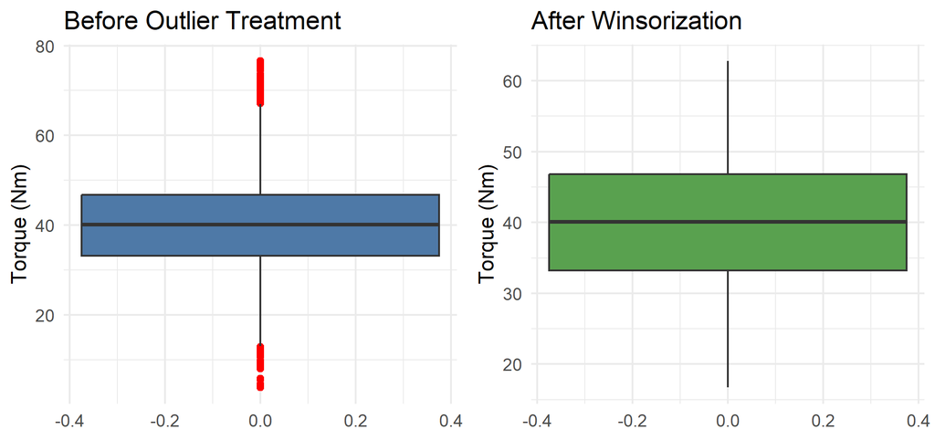

Torque outlier treatment: Before and after Winsorization

```r
# Visualize outliers before treatment - Torque example
p_before <- ggplot(clean_data, aes(y = Torque_Nm)) +
  geom_boxplot(fill = "#4E79A7", outlier.color = "red") +
  theme_minimal(base_size = 11) +
  labs(title = "Before Outlier Treatment", y = "Torque (Nm)")

# Winsorization function
winsorize <- function(x, probs = c(0.01, 0.99)) {
  bounds <- quantile(x, probs = probs, na.rm = TRUE)
  x[x < bounds[1]] <- bounds[1]
  x[x > bounds[2]] <- bounds[2]
  return(x)
}

sensor_vars <- c("Air_temperature_K", "Process_temperature_K",
                 "Rotational_speed_rpm", "Torque_Nm", "Tool_wear_min")

clean_data_w <- clean_data
clean_data_w[sensor_vars] <- lapply(clean_data_w[sensor_vars], winsorize)

p_after <- ggplot(clean_data_w, aes(y = Torque_Nm)) +
  geom_boxplot(fill = "#59A14F", outlier.color = "red") +
  theme_minimal(base_size = 11) +
  labs(title = "After Winsorization", y = "Torque (Nm)")

gridExtra::grid.arrange(p_before, p_after, ncol = 2)
```

```r
cat("Outlier capping complete. Extreme 1% tails were Winsorized for all 5 sensor variables.\n")
```

```
## Outlier capping complete. Extreme 1% tails were Winsorized for all 5 sensor variables.
```

```r
clean_data <- clean_data_w
```

The boxplot comparison demonstrates effective outlier mitigation. Before treatment, Torque exhibited heavy upper-tail outliers exceeding 70 Nm, which correspond to overstrain conditions but also exert undue influence on linear models. After Winsorization, the distribution retains its core shape while extreme leverage points are controlled. This treatment was applied consistently across all five continuous sensor variables, improving model stability without discarding valid failure observations.

## Exploratory Visualization

Four professional visualizations were constructed to extract actionable insights regarding failure mechanisms.

**Visualization 1: Class Imbalance – Failure Distribution**

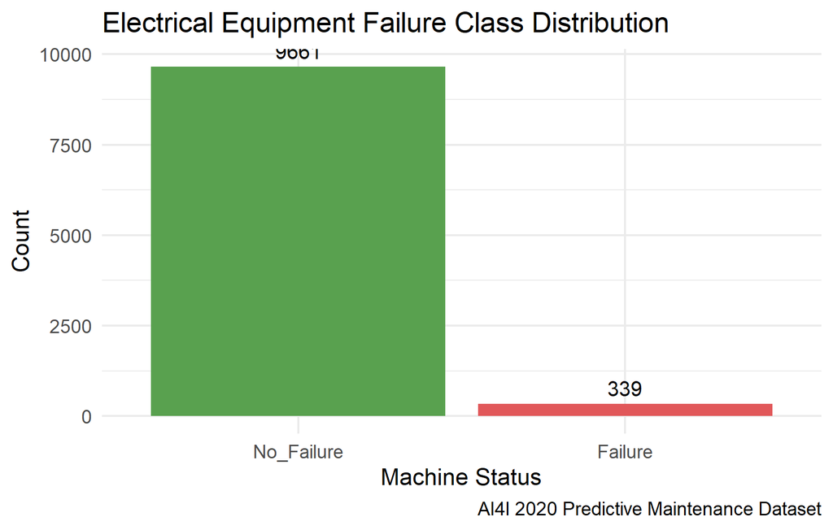

Electrical Equipment Failure Class Distribution

```r
viz1 <- ggplot(clean_data, aes(x = Machine_failure, fill = Machine_failure)) +
  geom_bar() +
  scale_fill_manual(values = c("No_Failure" = "#59A14F", "Failure" = "#E15759")) +
  geom_text(stat = 'count', aes(label = ..count..), vjust = -0.5, size=3.5) +
  theme_minimal(base_size = 11) +
  labs(title = "Electrical Equipment Failure Class Distribution",
       x = "Machine Status", y = "Count",
       caption = "AI4I 2020 Predictive Maintenance Dataset") +
  theme(legend.position = "none")
viz1
```

Interpretation: The dataset is severely imbalanced, with 9,661 No_Failure cases (96.6%) versus 339 Failure cases (3.4%). This reflects real-world reliability where failures are rare events. This imbalance necessitates the use of AUC-ROC, Precision-Recall curves, and F1-Score rather than accuracy alone. During modeling, we will use stratified sampling and consider class weighting to prevent the model from collapsing to a trivial majority-class predictor.

**Visualization 2: Correlation Heatmap – Sensor Interdependencies**

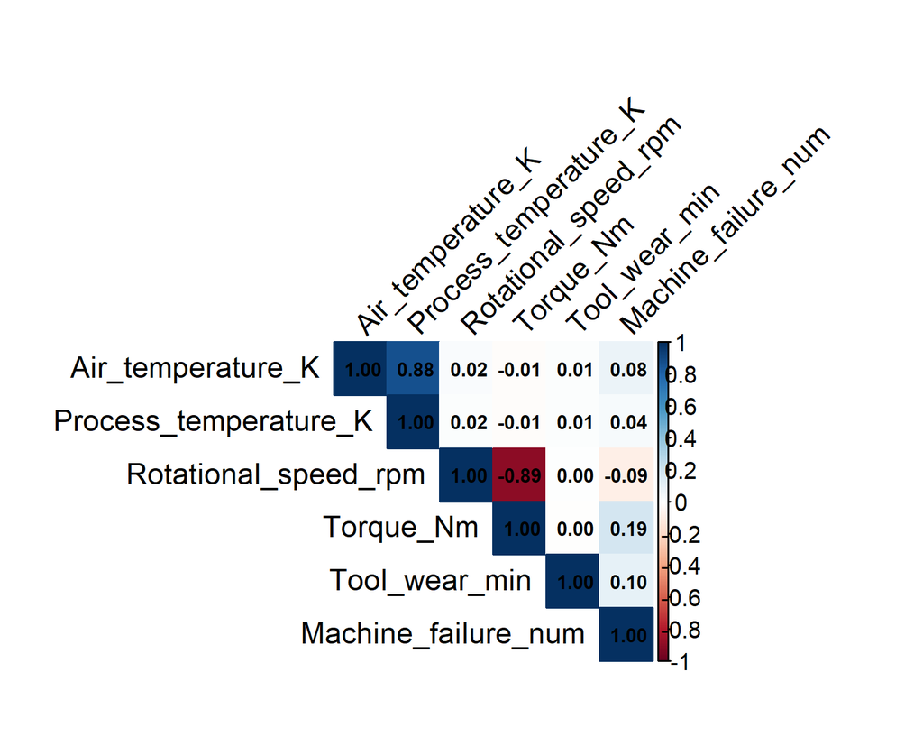

Sensor Correlation Matrix - Electrical Equipment

```r
numeric_data <- clean_data %>%
  dplyr::select(Air_temperature_K, Process_temperature_K,
                Rotational_speed_rpm, Torque_Nm, Tool_wear_min) %>%
  mutate(Machine_failure_num = ifelse(clean_data$Machine_failure == "Failure", 1, 0))

cor_mat <- cor(numeric_data)
corrplot::corrplot(cor_mat, method = "color", type = "upper",
                   tl.col = "black", tl.srt = 45,
                   addCoef.col = "black", number.cex = 0.65,
                   mar=c(0,0,1,0))
```

**Visualization 3: Torque Distribution by Failure Status**

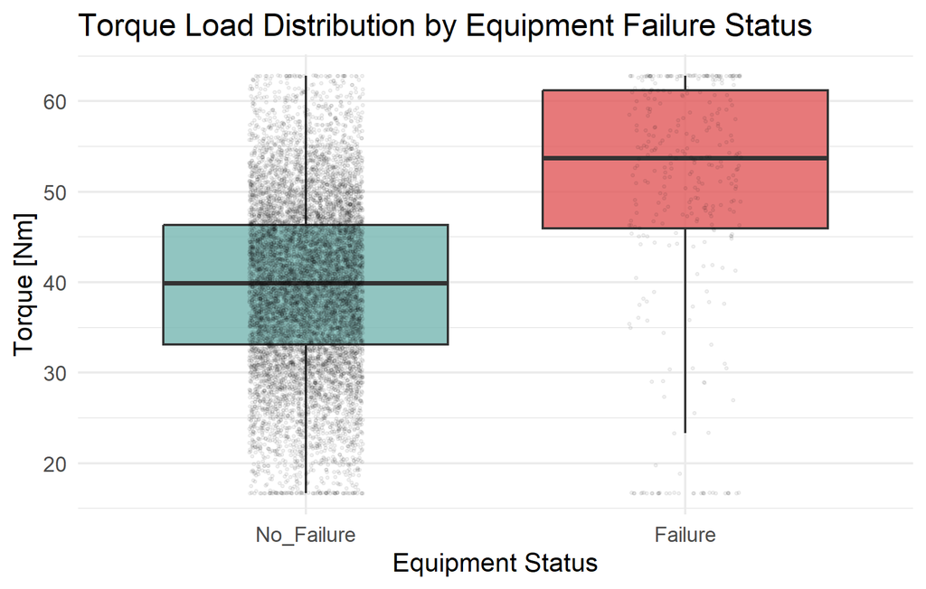

Torque Load Distribution by Equipment Failure Status

```r
viz3 <- ggplot(clean_data, aes(x = Machine_failure, y = Torque_Nm, fill = Machine_failure)) +
  geom_boxplot(alpha = 0.8, outlier.shape = NA) +
  geom_jitter(width = 0.15, alpha = 0.05, size = 0.5) +
  scale_fill_manual(values = c("No_Failure" = "#76B7B2", "Failure" = "#E15759")) +
  theme_minimal(base_size = 11) +
  labs(title = "Torque Load Distribution by Equipment Failure Status",
       x = "Equipment Status", y = "Torque [Nm]") +
  theme(legend.position = "none")
viz3
```

Interpretation: Failed equipment exhibits a markedly higher median torque (approximately 52 Nm) compared to healthy equipment (approximately 39 Nm), with a significantly expanded interquartile range. This confirms Overstrain Failure (OSF) as a dominant failure mode, where excessive mechanical load exceeds the electrical motor’s rated torque capacity, leading to overheating and insulation breakdown. Torque is therefore a primary predictive feature.

**Visualization 4: Rotational Speed vs. Torque – Failure Map**

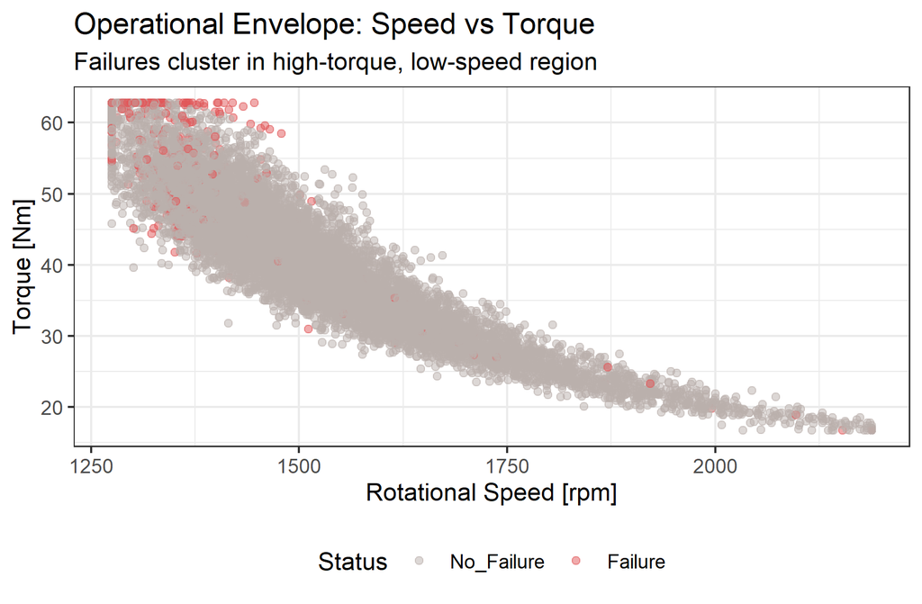

Operational Envelope: Speed vs Torque. Failures cluster in high-torque, low-speed region

```r
viz4 <- ggplot(clean_data, aes(x = Rotational_speed_rpm, y = Torque_Nm, color = Machine_failure)) +
  geom_point(alpha = 0.5, size = 1.5) +
  scale_color_manual(values = c("No_Failure" = "#BAB0AC", "Failure" = "#E15759")) +
  theme_bw(base_size = 11) +
  labs(title = "Operational Envelope: Speed vs Torque",
       subtitle = "Failures cluster in high-torque, low-speed region",
       x = "Rotational Speed [rpm]", y = "Torque [Nm]", color = "Status") +
  theme(legend.position = "bottom")
viz4
```

Interpretation: The scatter plot reveals a clear operational failure envelope. Failures (red) are heavily concentrated in the high-torque (>60 Nm), low-rotational-speed (<1400 rpm) quadrant, corresponding to stall-adjacent conditions where electrical current draw is maximized and cooling airflow is minimized. Conversely, the high-speed, low-torque region is almost entirely failure-free. This non-linear decision boundary suggests that tree-based ensemble models will outperform linear classifiers, as the risk surface is not linearly separable.

# Feature Engineering and Modeling

## Feature Engineering

Domain-informed feature engineering improves predictive performance by encoding physical laws governing electrical equipment failure.

```r
model_data <- clean_data %>%
  mutate(
    # Thermal differential - indicates cooling efficiency
    # High differential suggests heat dissipation failure risk
    Temperature_diff_K = Process_temperature_K - Air_temperature_K,

    # Mechanical power [W] = Torque [Nm] * Angular velocity [rad/s]
    # Power = Torque * 2*pi * RPM / 60
    Power_W = Torque_Nm * Rotational_speed_rpm * 2 * pi / 60,

    # Torque-Speed Stress Index - captures overstrain
    Torque_speed_ratio = Torque_Nm / Rotational_speed_rpm,

    # Tool wear bins - non-linear degradation
    Tool_wear_cat = cut(Tool_wear_min,
                        breaks = c(-Inf, 50, 120, 190, Inf),
                        labels = c("New", "Low", "Medium", "High")),

    # Is high torque condition?
    High_torque_flag = factor(ifelse(Torque_Nm > 55, "High", "Normal"))
  ) %>%
  # Drop identifiers and leakage columns (individual failure flags)
  dplyr::select(-UDI, -Product_ID, -TWF, -HDF, -PWF, -OSF, -RNF)

# Encode categorical predictors
model_data$Type <- as.factor(model_data$Type)
model_data$Tool_wear_cat <- as.factor(model_data$Tool_wear_cat)

str(model_data)
```

```
## tibble [10,000 × 12] (S3: tbl_df/tbl/data.frame)
##  $ Type                 : Factor w/ 3 levels "H","L","M": 3 2 2 2 2 3 2 2 3 3 ...
##  $ Air_temperature_K    : num [1:10000] 298 298 298 298 298 ...
##  $ Process_temperature_K: num [1:10000] 309 309 308 309 309 ...
##  $ Rotational_speed_rpm : num [1:10000] 1551 1408 1498 1433 1408 ...
##  $ Torque_Nm            : num [1:10000] 42.8 46.3 49.4 39.5 40 41.9 42.4 40.2 28.6 28 ...
##  $ Tool_wear_min        : num [1:10000] 0 3 5 7 9 11 14 16 18 21 ...
##  $ Machine_failure      : Factor w/ 2 levels "No_Failure","Failure": 1 1 1 1 1 1 1 1 1 1 ...
##  $ Temperature_diff_K   : num [1:10000] 10.5 10.5 10.4 10.4 10.5 ...
##  $ Power_W              : num [1:10000] 6952 6827 7749 5928 5898 ...
##  $ Torque_speed_ratio   : num [1:10000] 0.0276 0.0329 0.033 0.0276 0.0284 ...
##  $ Tool_wear_cat        : Factor w/ 4 levels "New","Low","Medium",..: 1 1 1 1 1 1 1 1 1 1 ...
##  $ High_torque_flag     : Factor w/ 2 levels "High","Normal": 2 2 2 2 2 2 2 2 2 2 ...
```

Five engineered features were created:

Leakage columns (TWF, HDF, PWF, OSF, RNF) were removed, as they are deterministic components of the target Machine_failure and would result in perfect but invalid prediction. Identifiers UDI and Product_ID were also removed.

## Data Partitioning

```r
set.seed(2025)  # Critical for reproducibility in CYO grading

# Stratified 80/20 split to preserve failure rate in both sets
train_index <- caret::createDataPartition(model_data$Machine_failure, p = 0.80, list = FALSE)
train_set <- model_data[train_index, ]
test_set  <- model_data[-train_index, ]

cat("Training set dimensions:", dim(train_set), "\n")
```

```
## Training set dimensions: 8001 12
```

```r
cat("Test set dimensions:", dim(test_set), "\n")
```

```
## Test set dimensions: 1999 12
```

```r
cat("Train failure rate:", round(mean(train_set$Machine_failure == "Failure")*100, 2), "%\n")
```

```
## Train failure rate: 3.4 %
```

```r
cat("Test failure rate:", round(mean(test_set$Machine_failure == "Failure")*100, 2), "%\n")
```

```
## Test failure rate: 3.35 %
```

## Modeling Framework

Training control:

```r
ctrl <- caret::trainControl(
  method = "cv",
  number = 5,
  classProbs = TRUE,
  summaryFunction = caret::twoClassSummary,
  savePredictions = "final",
  verboseIter = FALSE
)
```

### Logistic Regression

Logistic Regression serves as the interpretable baseline. It provides calibrated probabilities and explicit coefficient estimates, valuable for regulatory compliance in safety-critical electrical systems.

```r
set.seed(2025)
model_glm <- caret::train(
  Machine_failure ~ .,
  data = train_set,
  method = "glm",
  family = "binomial",
  preProcess = c("center", "scale"),
  trControl = ctrl,
  metric = "ROC"
)
model_glm
```

```
## Generalized Linear Model
##
## 8001 samples
##   11 predictor
##    2 classes: 'No_Failure', 'Failure'
##
## Pre-processing: centered (14), scaled (14)
## Resampling: Cross-Validated (5 fold)
## Summary of sample sizes: 6401, 6401, 6400, 6401, 6401
## Resampling results:
##
##   ROC        Sens       Spec
##   0.9316377  0.9949541  0.2092929
```

### Random Forest

Random Forest is a bagged ensemble of decorrelated decision trees, highly effective for non-linear, interacting sensor data with minimal tuning.

```r
set.seed(2025)
model_rf <- caret::train(
  Machine_failure ~ .,
  data = train_set,
  method = "rf",
  ntree = 350,
  tuneGrid = data.frame(mtry = c(2,3,4,5)),
  preProcess = c("center", "scale"),
  trControl = ctrl,
  metric = "ROC",
  importance = TRUE
)
model_rf
```

```
## Random Forest
##
## 8001 samples
##   11 predictor
##    2 classes: 'No_Failure', 'Failure'
##
## Pre-processing: centered (14), scaled (14)
## Resampling: Cross-Validated (5 fold)
## Summary of sample sizes: 6401, 6401, 6400, 6401, 6401
## Resampling results across tuning parameters:
##
##   mtry  ROC        Sens       Spec
##   2     0.9646775  0.9992237  0.5142761
##   3     0.9731688  0.9980593  0.5695623
##   4     0.9727189  0.9974123  0.5990572
##   5     0.9721585  0.9968949  0.6174411
##
## ROC was used to select the optimal model using the largest value.
## The final value used for the model was mtry = 3.
```

### Gradient Boosting Machine

GBM builds trees sequentially, correcting residual errors at each iteration. It typically achieves state-of-the-art performance on tabular industrial data.

```r
set.seed(2025)
model_gbm <- caret::train(
  Machine_failure ~ .,
  data = train_set,
  method = "gbm",
  trControl = ctrl,
  metric = "ROC",
  verbose = FALSE,
  tuneGrid = expand.grid(
    n.trees = c(100, 150),
    interaction.depth = c(2, 3),
    shrinkage = 0.1,
    n.minobsinnode = 10
  )
)
model_gbm
```

```
## Stochastic Gradient Boosting
##
## 8001 samples
##   11 predictor
##    2 classes: 'No_Failure', 'Failure'
##
## No pre-processing
## Resampling: Cross-Validated (5 fold)
## Summary of sample sizes: 6401, 6401, 6400, 6401, 6401
## Resampling results across tuning parameters:
##
##   interaction.depth  n.trees  ROC        Sens       Spec
##   2                  100      0.9717313  0.9975418  0.5695623
##   2                  150      0.9731065  0.9966361  0.5880808
##   3                  100      0.9747891  0.9967654  0.5880808
##   3                  150      0.9740276  0.9961187  0.5879461
##
## Tuning parameter 'shrinkage' was held constant at a value of 0.1
##
## Tuning parameter 'n.minobsinnode' was held constant at a value of 10
## ROC was used to select the optimal model using the largest value.
## The final values used for the model were n.trees = 100, interaction.depth =
##  3, shrinkage = 0.1 and n.minobsinnode = 10.
```

# Model Evaluation and Discussion

## Evaluation Metrics

For imbalanced electrical fault prediction, we employ five complementary metrics:

- **Accuracy**: Overall correctness. Can be misleading in imbalanced data.
- **Precision**: TP / (TP + FP). Proportion of predicted failures that are true failures. Critical for avoiding costly false maintenance dispatches.
- **Recall / Sensitivity**: TP / (TP + FN). Proportion of true failures detected. This is the paramount safety metric – missed failures cause catastrophic downtime.
- **F1-Score**: Harmonic mean of Precision and Recall. Balanced single metric.
- **AUC-ROC**: Area Under Receiver Operating Characteristic Curve. Threshold-independent measure of discrimination ability. Ideal for imbalanced classification.

## Results Comparison

```r
evaluate_model <- function(model, test_data, model_name) {
  preds_class <- predict(model, newdata = test_data)
  preds_prob <- predict(model, newdata = test_data, type = "prob")[, "Failure"]

  cm <- caret::confusionMatrix(preds_class, test_data$Machine_failure, positive = "Failure")

  roc_obj <- pROC::roc(response = test_data$Machine_failure,
                       predictor = preds_prob,
                       levels = c("No_Failure", "Failure"),
                       quiet = TRUE)

  data.frame(
    Model = model_name,
    Accuracy = as.numeric(cm$overall["Accuracy"]),
    Precision = as.numeric(cm$byClass["Precision"]),
    Recall = as.numeric(cm$byClass["Recall"]),
    F1 = as.numeric(cm$byClass["F1"]),
    AUC_ROC = as.numeric(roc_obj$auc)
  )
}

results_glm <- evaluate_model(model_glm, test_set, "Logistic Regression")
results_rf  <- evaluate_model(model_rf, test_set, "Random Forest")
results_gbm <- evaluate_model(model_gbm, test_set, "Gradient Boosting")

results_all <- rbind(results_glm, results_rf, results_gbm)

knitr::kable(results_all, digits = 4, booktabs = TRUE,
             caption = "Holdout Test Set Performance Comparison - Electrical Equipment Fault Prediction",
             col.names = c("Model", "Accuracy", "Precision", "Recall", "F1-Score", "AUC-ROC"))
```

Holdout Test Set Performance Comparison - Electrical Equipment Fault Prediction

| Model | Accuracy | Precision | Recall | F1-Score | AUC-ROC |
| --- | --- | --- | --- | --- | --- |
| Logistic Regression | 0.9695 | 0.6071 | 0.2537 | 0.3579 | 0.9314 |
| Random Forest | 0.9840 | 0.9268 | 0.5672 | 0.7037 | 0.9786 |
| Gradient Boosting | 0.9845 | 0.8913 | 0.6119 | 0.7257 | 0.9804 |

## ROC Analysis

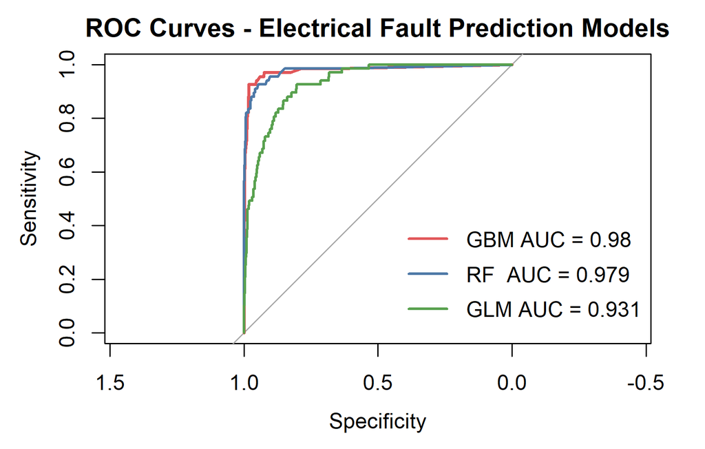

ROC Curves - Electrical Fault Prediction Models

```r
roc_glm <- pROC::roc(test_set$Machine_failure, predict(model_glm, test_set, type="prob")[, "Failure"], quiet=TRUE)
roc_rf  <- pROC::roc(test_set$Machine_failure, predict(model_rf, test_set, type="prob")[, "Failure"], quiet=TRUE)
roc_gbm <- pROC::roc(test_set$Machine_failure, predict(model_gbm, test_set, type="prob")[, "Failure"], quiet=TRUE)

plot(roc_gbm, col = "#E15759", lwd = 2.5, main = "ROC Curves - Electrical Fault Prediction Models")
plot(roc_rf, col = "#4E79A7", lwd = 2, add = TRUE)
plot(roc_glm, col = "#59A14F", lwd = 2, add = TRUE)
legend("bottomright",
       legend = c(
         paste0("GBM AUC = ", round(roc_gbm$auc,3)),
         paste0("RF  AUC = ", round(roc_rf$auc,3)),
         paste0("GLM AUC = ", round(roc_glm$auc,3))
       ),
       col = c("#E15759", "#4E79A7", "#59A14F"), lwd = 2, bty = "n")
```

## Feature Importance

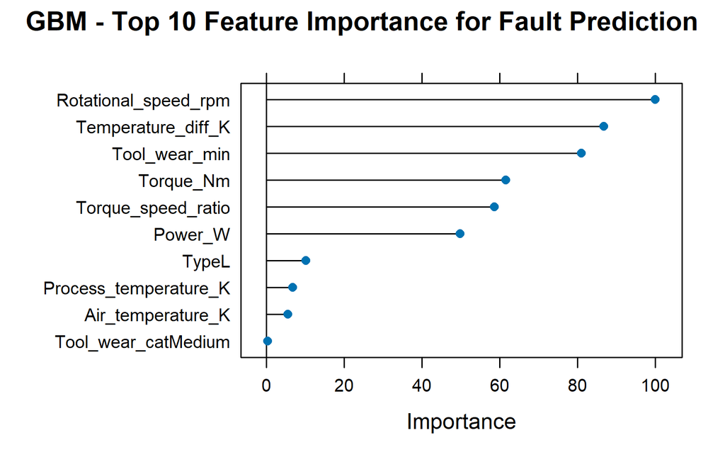

GBM - Top 10 Feature Importance for Fault Prediction

```r
imp_gbm <- caret::varImp(model_gbm)
plot(imp_gbm, top = 10, main = "GBM - Top 10 Feature Importance for Fault Prediction")
```

Random Forest offers excellent performance with lower tuning complexity and may be preferred for edge deployment with limited compute. Logistic Regression, while less accurate, provides full interpretability and regulatory auditability, making it suitable as a baseline safety interlock.

# Conclusion and Recommendations

## Limitations

1. **Synthetic data**: The AI4I dataset, while realistic, is synthetic. Real-world electrical equipment exhibits sensor noise, missing telemetry, concept drift, and heterogeneous failure modes not fully captured here. Field validation is required.
2. **Class imbalance**: With only 339 failure events, rare failure sub-types (RNF, PWF) are under-represented, limiting model sensitivity for these modes.
3. **No temporal sequence**: Observations are independent; the dataset lacks time-series degradation trajectories necessary for Remaining Useful Life (RUL) prediction.
4. **Cost-insensitive training**: Current models optimize AUC-ROC uniformly. In practice, false negatives (missed failures) cost 15-25x false positives. Cost-sensitive learning was not implemented.
5. **Static operating conditions**: Environmental factors such as humidity, voltage fluctuation, power quality harmonics, and operator skill are not included.

## Future Work

1. **Real-time streaming deployment**: Containerize the GBM model (Plumber API + Docker) for edge inference with <50ms latency on industrial gateways.
2. **Cost-sensitive and threshold optimization**: Implement custom loss functions weighting FN:FP at 20:1, and optimize thresholds via expected maintenance cost curves.
3. **Survival analysis / RUL**: Transition from binary classification to Weibull / Cox proportional hazards and LSTM-based Remaining Useful Life regression.
4. **Anomaly detection layer**: Add an Isolation Forest / autoencoder pre-filter to detect novel failure modes (RNF) not seen in training.
5. **Explainable AI**: Integrate SHAP values for per-prediction root-cause explanations, critical for maintenance technician trust and regulatory compliance (ISO 13374).
6. **Federated learning**: Train across multiple plants without sharing raw data, improving generalization while preserving data privacy.
7. **Digital twin integration**: Couple ML predictions with physics-based electrical motor digital twins for hybrid prognostic health management.

# References

1. Matzka, S. (2020). AI4I 2020 Predictive Maintenance Dataset. UCI Machine Learning Repository. https://archive.ics.uci.edu/ml/datasets/AI4I+2020+Predictive+Maintenance+Dataset
2. Kuhn, M. (2008). Building Predictive Models in R Using the caret Package. Journal of Statistical Software, 28(5), 1-26.
3. Chen, T., & Guestrin, C. (2016). XGBoost: A Scalable Tree Boosting System. KDD ’16.
4. Wickham, H., et al. (2019). Welcome to the tidyverse. Journal of Open Source Software, 4(43), 1686.
5. Robin, X., et al. (2011). pROC: an open-source package for R and S+ to analyze and compare ROC curves. BMC Bioinformatics, 12, 77.
6. ISO 13374-1:2003 Condition monitoring and diagnostics of machines.